# Option A — our cores, and how they compare

06 October 2026

**Cowichan Estuary eelgrass — worked example**

> **What this report is.** A description of the cores that were measured, and where they sit among published eelgrass cores. Each core describes the place it was taken. This report does not estimate the carbon in a whole meadow — that needs a defined area and a sampling design (Option B).

## 1. The question

What do three eelgrass cores tell us about sediment organic carbon at Cowichan, and how do they compare with other eelgrass meadows?

## 2. What was sampled

| Area and habitat | Cowichan Estuary, British Columbia — eelgrass (Zostera marina) sediment |
| --- | --- |
| Survey dates | Not given in the compiled dataset (see Douglas et al. 2022) |
| How the cores were placed | Three stations chosen by the original study to be representative of the meadow (not randomly placed) |
| Cores in this report | 3 complete core(s), from 3 plot(s) |
| Data source | Douglas, Schuerholz & Juniper (2022), Frontiers in Marine Science 9:857586, as compiled in Janousek et al. (2025), doi:10.25573/serc.28127486 |
| Prepared by | Blue Carbon Eelgrass Workshop |

Each slice is one measurement *within* a core, not an independent sample of the meadow. Cores sharing a plot are not independent of each other either.

## 3. Carbon pool and depth

**Sediment organic carbon** only — not living eelgrass, roots, or total ecosystem carbon. Stocks are given for the standard depth increments (0–15, 15–30, 30–50, 50–100 cm) on in-situ depths, and only where a core reached the bottom of the increment. Cores are compared over **0–15 cm**, the deepest standard depth every complete core reached.

## 4. How the numbers were calculated

- **Methods:** Push cores (7.6 cm acrylic tubes), 1–2 cm slices; organic carbon by elemental analyser after acid fumigation on some slices, loss on ignition (550 °C) on the rest, converted with a local calibration.
- **Slice stock** (Mg C/ha) = dry bulk density (g/cm³) × organic carbon (%) ÷ 100 × slice thickness in the tube (cm) × 100. Bulk density = whole-slice dry mass ÷ slice volume, from the corer’s internal diameter (7.6 cm on the Instructions tab unless a core gives its own).
- **Organic carbon:** 64% of slices came from loss on ignition, converted with OC% = -0.197 + 0.32 × LOI%. The rest are elemental organic carbon. Total carbon is never used as organic carbon.
- **Compaction:** assumed none for 3 core(s). Compaction moves each slice to its in-situ depth; it never changes how much carbon the slice holds.
- **Increments:** a slice that crosses an increment boundary is split in proportion to its overlap, so the increments add up to exactly the carbon measured.
- Nothing is interpolated, smoothed or extrapolated in this report.

## 5. Checks

| Core | Plot | Slices | Slices OK | Status |
| --- | --- | --- | --- | --- |
| COW-S5 | S5 | 15 | 15 | Complete |
| COW-S6 | S6 | 15 | 15 | Complete |
| COW-S7 | S7 | 15 | 15 | Complete |

The R workflow re-calculates every slice independently of the workbook. Largest difference from the workbook’s own numbers:

| Quantity | Largest difference |
| --- | --- |
| bulk density (g/cm3) | agrees (< 0.000001) |
| organic carbon (%) | agrees (< 0.000001) |
| stock (kg C/m2) | agrees (< 0.000001) |
| corer diameter used (cm) | agrees (< 0.000001) |
| slice checks that differ (count) | 0 |
| core checks that differ (count) | 0 |
| values present in one but not the other (count) | 0 |

## 6. What the cores show

Organic carbon stock by standard increment (Mg C/ha). ‘partial’ = the core ends inside the increment, so its value is not comparable.

| Core | Measured to (cm, in situ) | Bulk density (g/cm³) | Organic carbon (%) | 0–15 cm | 15–30 cm | 30–50 cm | 50–100 cm |
| --- | --- | --- | --- | --- | --- | --- | --- |
| COW-S5 | 20.0 | 1.74 | 0.64 | 17.1 | partial | not reached | not reached |
| COW-S6 | 20.0 | 1.65 | 0.66 | 12.1 | partial | not reached | not reached |
| COW-S7 | 20.0 | 1.76 | 0.53 | 14.5 | partial | not reached | not reached |

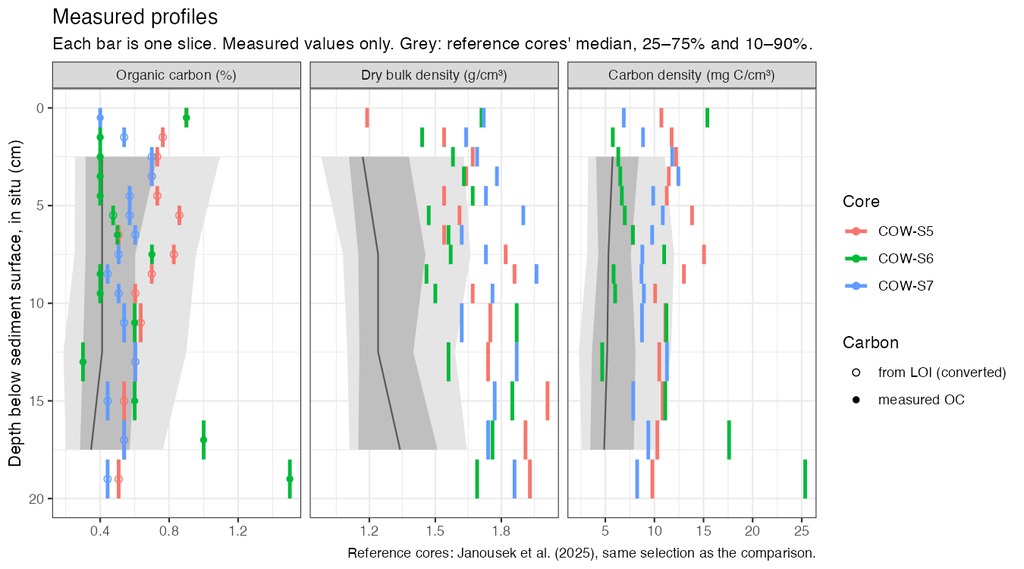

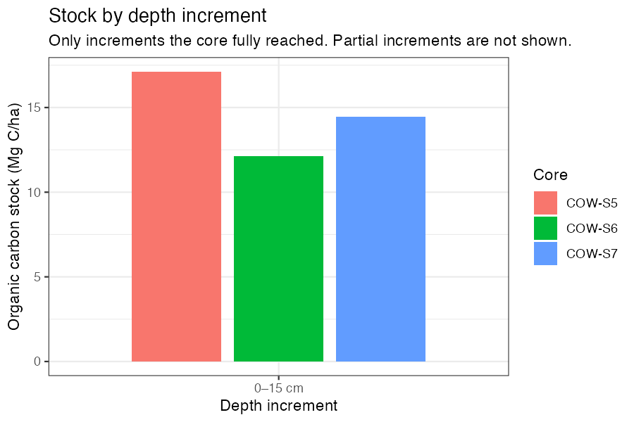

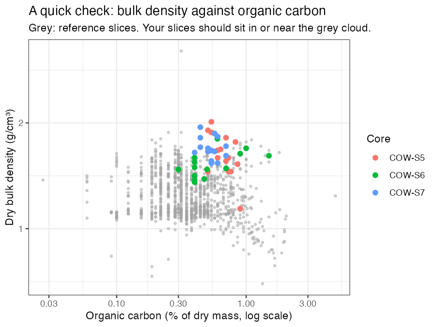

A slice far outside the grey cloud is worth re-checking before anything else: a wrong corer diameter, or a subsample’s dry mass set against the whole slice’s volume, both show up here first.

## 7. How the cores compare with published eelgrass cores

**What the reference distribution is.** The grey points are individual *Zostera marina* cores from BC + WA, compiled by Janousek et al. (2025), measured continuously to at least 15 cm. They come from different studies, estuaries and years, chosen by their authors for their own purposes. They show the range other eelgrass meadows have produced — they are not a random sample of all eelgrass, and they are not a target.

To keep the comparison fair, the reference set leaves out: your own estuary (COW); any core within 100 m of one of your cores (so a published core used as practice data can never be compared with itself); and any slice the synthesis marks as estimated rather than measured.

Two reference sets are shown, because carbon was measured in two ways:

Organic carbon stock, 0–15 cm (Mg C/ha)

| Reference set | Cores | Estuaries | Studies | Min | Lower quartile | Median | Upper quartile | Max |
| --- | --- | --- | --- | --- | --- | --- | --- | --- |
| Measured OC + LOI converted with your equation | 53 | 8 | 6 | 1.0 | 6.3 | 7.8 | 11.1 | 23.7 |
| Measured OC only (studies that removed inorganic carbon) | 8 | 2 | 2 | 6.2 | 7.9 | 10.2 | 11.6 | 21.1 |

The headline set is **Measured OC + LOI converted with your equation**. Its LOI values were converted with the same equation as your own LOI slices, so both sides of the comparison share the same conversion — but the conversion was fitted on your samples, and the published sediments may relate LOI to carbon differently. The measured-only set avoids that, but it is small.

| Core | Stock 0–15 cm (Mg C/ha) | Note | Percentile — OC + converted LOI (headline) | Percentile — measured OC only |
| --- | --- | --- | --- | --- |
| COW-S5 | 17.1 |  | 87 | 88 |
| COW-S6 | 12.1 |  | 77 | 75 |
| COW-S7 | 14.5 |  | 83 | 88 |

A percentile is the share of reference cores with a stock at or below yours. It describes where a core sits; it is not a statistical test, and with a small reference set it moves in large steps.

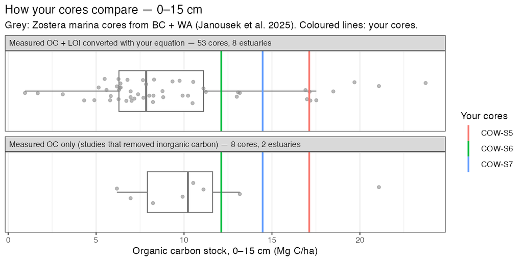

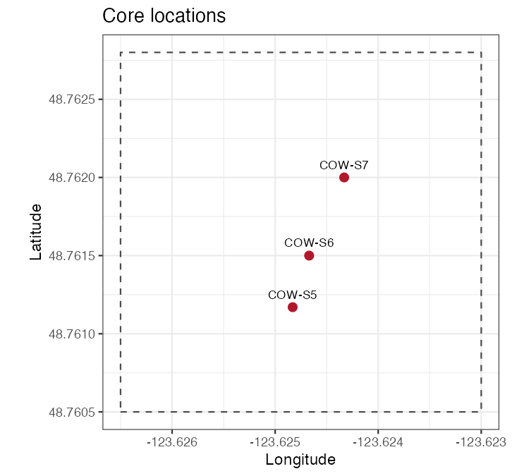

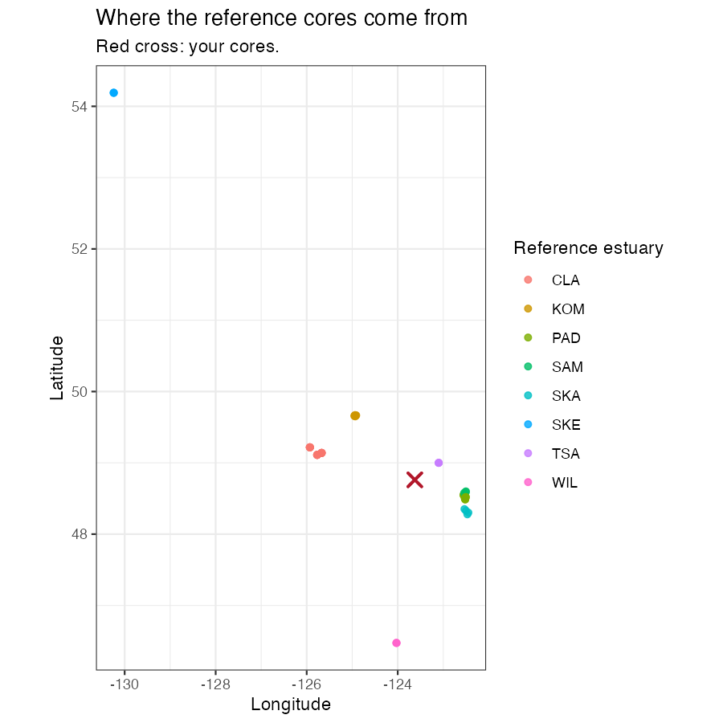

How the headline reference set was chosen

| Step | Cores |
| --- | --- |
| Zostera cores in the synthesis | 240 |
| In the chosen region | 114 |
| After excluding your estuary | 111 |
| After excluding cores within 100 m of yours | 111 |
| Measured continuously to 15 cm on this carbon basis | 53 |

## 8. Missing data, exclusions and limitations

- Cores not in the tables above did not pass the checks in section 5, or did not reach 15 cm.
- Compaction was not measured for 3 of 3 cores and was assumed to be none; if those cores were compacted, their slices sit deeper than shown.
- 64% of slices are LOI converted with a fitted equation. That conversion has its own error, which is not shown in any number here.
- Reference-core depths are as published, not corrected for compaction.
- Stocks below the base of a core are unknown here. A core’s total is only comparable with another core’s over the same depth.

## 9. What this supports, and what would help

**Supports:** a description of sediment organic carbon at the places these cores were taken, over 0–15 cm, and where those values sit among published eelgrass cores from the region.

**Does not support:** a meadow-wide average, a total for an area, an interval around a mean, or any statement about carbon being added (sequestration) — that needs dated cores.

**What would help:** more cores, placed with a sampling design (Part 2), to describe the meadow rather than single points; deeper cores to compare over 0–30 cm or more; elemental organic carbon on a subset of slices to check the LOI conversion; measured compaction on every core.